# **Red Wine Exploration**

Jake Neyer  
January 14, 2018

## **Taking a Peek at the Dataset**

```
## 'data.frame':    1599 obs. of  13 variables:
##  $ X                   : int  1 2 3 4 5 6 7 8 9 10 ...
##  $ fixed.acidity       : num  7.4 7.8 7.8 11.2 7.4 7.4 7.9 7.3 7.8 7.5 ...
##  $ volatile.acidity    : num  0.7 0.88 0.76 0.28 0.7 0.66 0.6 0.65 0.58 0.5 ...
##  $ citric.acid         : num  0 0 0.04 0.56 0 0 0.06 0 0.02 0.36 ...
##  $ residual.sugar      : num  1.9 2.6 2.3 1.9 1.9 1.8 1.6 1.2 2 6.1 ...
##  $ chlorides           : num  0.076 0.098 0.092 0.075 0.076 0.075 0.069 0.065 0.073 0.071 ...
##  $ free.sulfur.dioxide : num  11 25 15 17 11 13 15 15 9 17 ...
##  $ total.sulfur.dioxide: num  34 67 54 60 34 40 59 21 18 102 ...
##  $ density             : num  0.998 0.997 0.997 0.998 0.998 ...
##  $ pH                  : num  3.51 3.2 3.26 3.16 3.51 3.51 3.3 3.39 3.36 3.35 ...
##  $ sulphates           : num  0.56 0.68 0.65 0.58 0.56 0.56 0.46 0.47 0.57 0.8 ...
##  $ alcohol             : num  9.4 9.8 9.8 9.8 9.4 9.4 9.4 10 9.5 10.5 ...
##  $ quality             : int  5 5 5 6 5 5 5 7 7 5 ...
```

## **Dataset Metadata**

**Input variables (based on physicochemical tests):**

1 - fixed acidity: most acids involved with wine or fixed or nonvolatile (do  
not evaporate readily)

2 - volatile acidity: the amount of acetic acid in wine, which at too high of  
levels can lead to an unpleasant, vinegar taste

3 - citric acid: found in small quantities, citric acid can add ‘freshness’ and  
flavor to wines

4 - residual sugar: the amount of sugar remaining after fermentation stops, it’s  
rare to find wines with less than 1 gram/liter and wines with greater than 45  
grams/liter are considered sweet

5 - chlorides: the amount of salt in the wine

6 - free sulfur dioxide: the free form of SO2 exists in equilibrium between  
molecular SO2 (as a dissolved gas) and bisulfite ion; it prevents microbial  
growth and the oxidation of wine

7 - total sulfur dioxide: amount of free and bound forms of S02; in low concentrations,  
SO2 is mostly undetectable in wine, but at free SO2 concentrations over 50 ppm, SO2  
becomes evident in the nose and taste of wine

8 - density: the density of water is close to that of water depending on the  
percent alcohol and sugar content

9 - pH: describes how acidic or basic a wine is on a scale from 0 (very acidic)  
to 14 (very basic); most wines are between 3-4 on the pH scale

10 - sulphates: a wine additive which can contribute to sulfur dioxide gas (S02)  
levels, wich acts as an antimicrobial and antioxidant

11 - alcohol: the percent alcohol content of the wine

**Output variable (based on sensory data):**

12 - quality (score between 0 and 10)

And a more human-readable version:

| X | fixed.acidity | volatile.acidity | citric.acid | residual.sugar | chlorides | free.sulfur.dioxide | total.sulfur.dioxide | density | pH | sulphates | alcohol | quality |
| --- | --- | --- | --- | --- | --- | --- | --- | --- | --- | --- | --- | --- |
| 1 | 7.4 | 0.70 | 0.00 | 1.9 | 0.076 | 11 | 34 | 0.9978 | 3.51 | 0.56 | 9.4 | 5 |
| 2 | 7.8 | 0.88 | 0.00 | 2.6 | 0.098 | 25 | 67 | 0.9968 | 3.20 | 0.68 | 9.8 | 5 |
| 3 | 7.8 | 0.76 | 0.04 | 2.3 | 0.092 | 15 | 54 | 0.9970 | 3.26 | 0.65 | 9.8 | 5 |
| 4 | 11.2 | 0.28 | 0.56 | 1.9 | 0.075 | 17 | 60 | 0.9980 | 3.16 | 0.58 | 9.8 | 6 |
| 5 | 7.4 | 0.70 | 0.00 | 1.9 | 0.076 | 11 | 34 | 0.9978 | 3.51 | 0.56 | 9.4 | 5 |
| 6 | 7.4 | 0.66 | 0.00 | 1.8 | 0.075 | 13 | 40 | 0.9978 | 3.51 | 0.56 | 9.4 | 5 |

## **Univariate Plots Section**

Checking out the acidity of the wines:

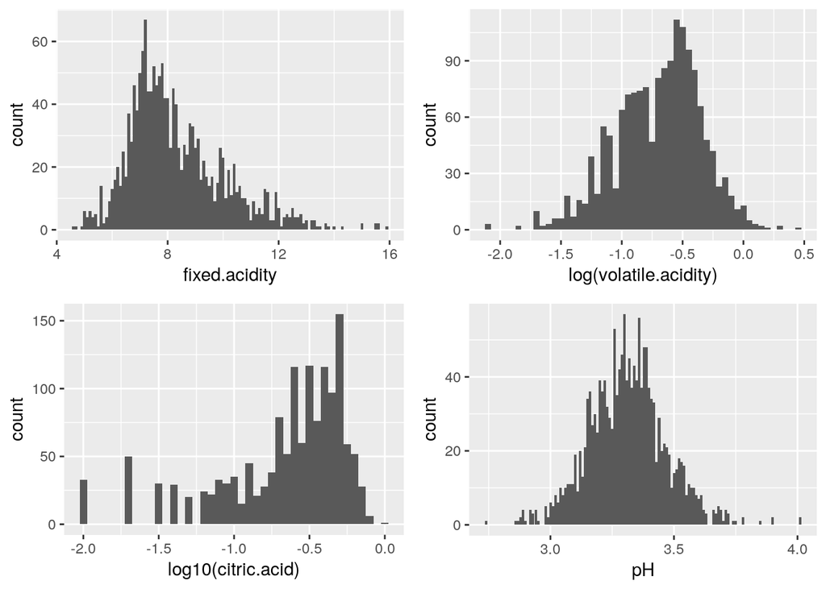

Barring citric acid content, the acidity seems to generally be normally distrobuted.  
Fixed acidity is centered around 6-8g/dm^3 and violatile acidity is generally between  
0.4 and 0.7g/dm^3. I will look more into this in the following section. In order to normalize  
volatile acid and citric acid contents, I performed a logrithmic transformations on  
the two variables.

Taking a look at the other factors:

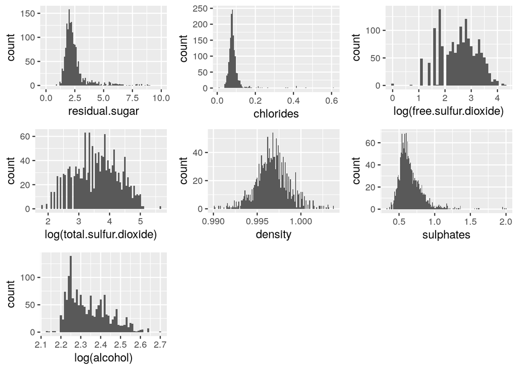

In order to get a more normally distributed graph of SO2 and alcohol content, I  
performed a few more logrithmic transformations.

Taking a look at quality distrobutions:

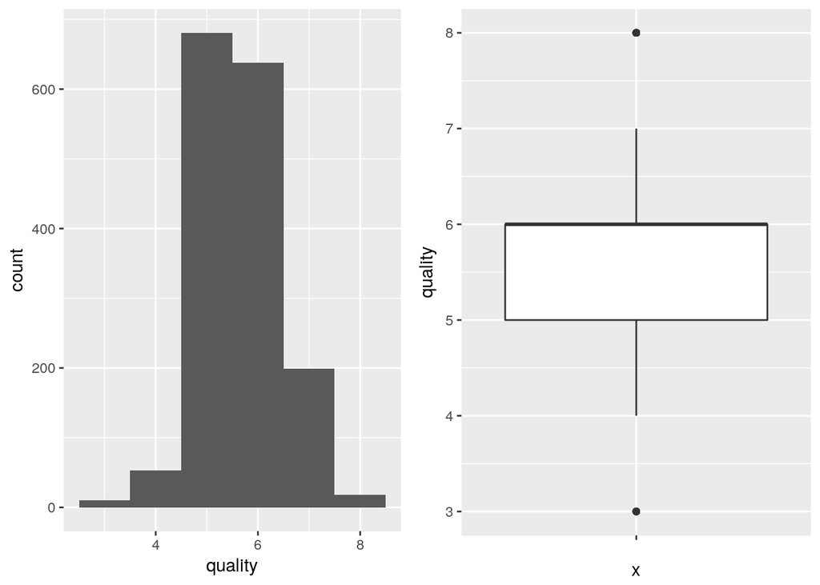

```
##    Min. 1st Qu.  Median    Mean 3rd Qu.    Max.
##   3.000   5.000   6.000   5.636   6.000   8.000
```

Quality ratings of 5 and 6 are extremely common; more so than any other.

## **Univariate Analysis**

```
##        X          fixed.acidity   volatile.acidity  citric.acid
##  Min.   :   1.0   Min.   : 4.60   Min.   :0.1200   Min.   :0.000
##  1st Qu.: 400.5   1st Qu.: 7.10   1st Qu.:0.3900   1st Qu.:0.090
##  Median : 800.0   Median : 7.90   Median :0.5200   Median :0.260
##  Mean   : 800.0   Mean   : 8.32   Mean   :0.5278   Mean   :0.271
##  3rd Qu.:1199.5   3rd Qu.: 9.20   3rd Qu.:0.6400   3rd Qu.:0.420
##  Max.   :1599.0   Max.   :15.90   Max.   :1.5800   Max.   :1.000
##  residual.sugar     chlorides       free.sulfur.dioxide
##  Min.   : 0.900   Min.   :0.01200   Min.   : 1.00
##  1st Qu.: 1.900   1st Qu.:0.07000   1st Qu.: 7.00
##  Median : 2.200   Median :0.07900   Median :14.00
##  Mean   : 2.539   Mean   :0.08747   Mean   :15.87
##  3rd Qu.: 2.600   3rd Qu.:0.09000   3rd Qu.:21.00
##  Max.   :15.500   Max.   :0.61100   Max.   :72.00
##  total.sulfur.dioxide    density             pH          sulphates
##  Min.   :  6.00       Min.   :0.9901   Min.   :2.740   Min.   :0.3300
##  1st Qu.: 22.00       1st Qu.:0.9956   1st Qu.:3.210   1st Qu.:0.5500
##  Median : 38.00       Median :0.9968   Median :3.310   Median :0.6200
##  Mean   : 46.47       Mean   :0.9967   Mean   :3.311   Mean   :0.6581
##  3rd Qu.: 62.00       3rd Qu.:0.9978   3rd Qu.:3.400   3rd Qu.:0.7300
##  Max.   :289.00       Max.   :1.0037   Max.   :4.010   Max.   :2.0000
##     alcohol         quality
##  Min.   : 8.40   Min.   :3.000
##  1st Qu.: 9.50   1st Qu.:5.000
##  Median :10.20   Median :6.000
##  Mean   :10.42   Mean   :5.636
##  3rd Qu.:11.10   3rd Qu.:6.000
##  Max.   :14.90   Max.   :8.000
```

The dataset contains 1599 red wines with 13 features. Quality is rated on a scale  
from 0 (Very Bad) to 10 (Very Excellent). The most common quality ratings are 5 and  
6 in this particular dataset. I wonder which features play the largest role in determing  
the quality rating. I am also curious to better understand how different variables  
affect others, such as alcohol content and density or acidity and residual sugar.  
In the following section I will begin to understand how the different variables interact  
and also understand which variables play roles in determining the overall quality of  
the wine.

## **Bivariate Plots Section**

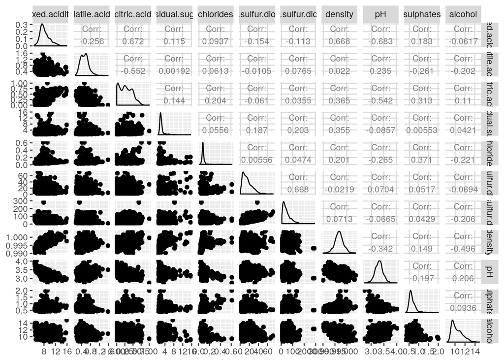

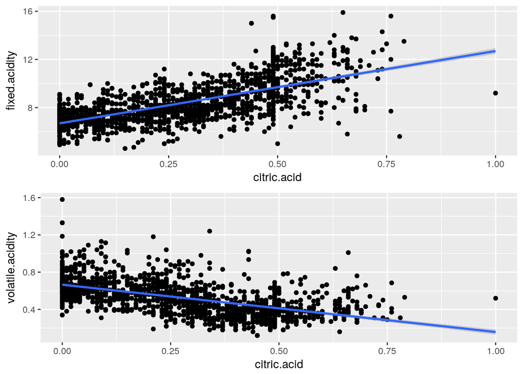

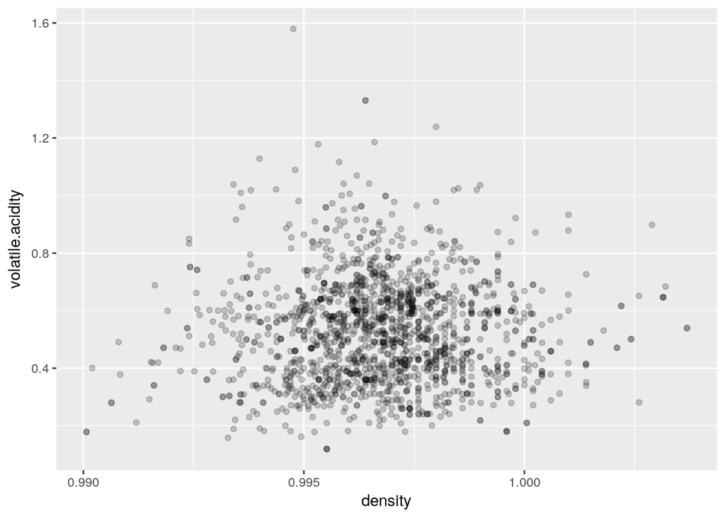

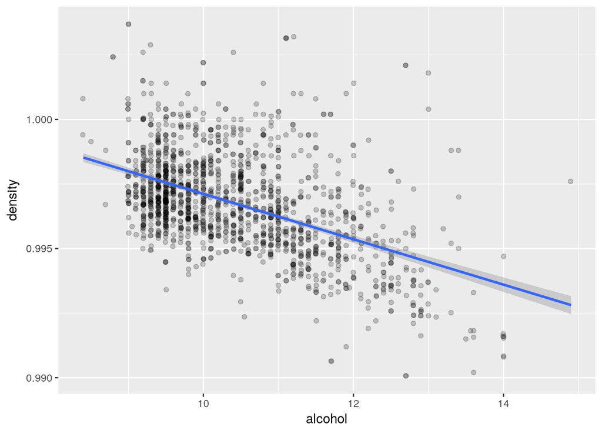

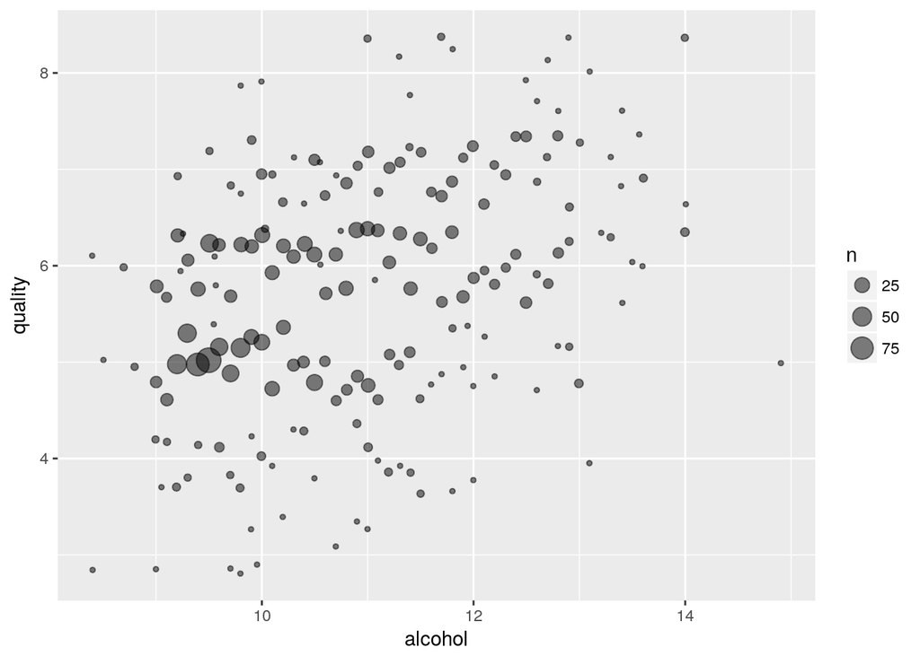

## **Bivariate Analysis**

Here is a detailed breakdown of the input variables relationship with the wine quality:

```
##                             [,1]
## X                     0.06645261
## fixed.acidity         0.12405165
## volatile.acidity     -0.39055778
## citric.acid           0.22637251
## residual.sugar        0.01373164
## chlorides            -0.12890656
## free.sulfur.dioxide  -0.05065606
## total.sulfur.dioxide -0.18510029
## density              -0.17491923
## pH                   -0.05773139
## sulphates             0.25139708
## alcohol               0.47616632
## quality               1.00000000
```

## **Multivariate Plots**

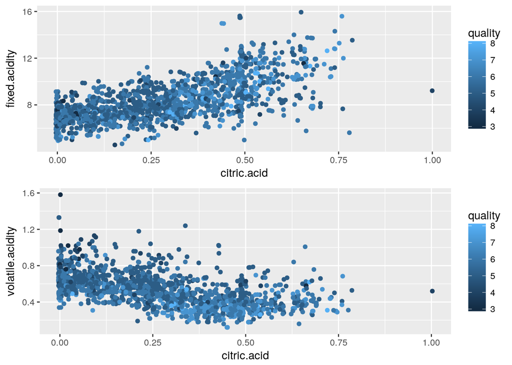

The quality scale is difficult to visualize. Breaking the ratings into larger levels  
will help visualize the data more easily.

Running it again I get this:

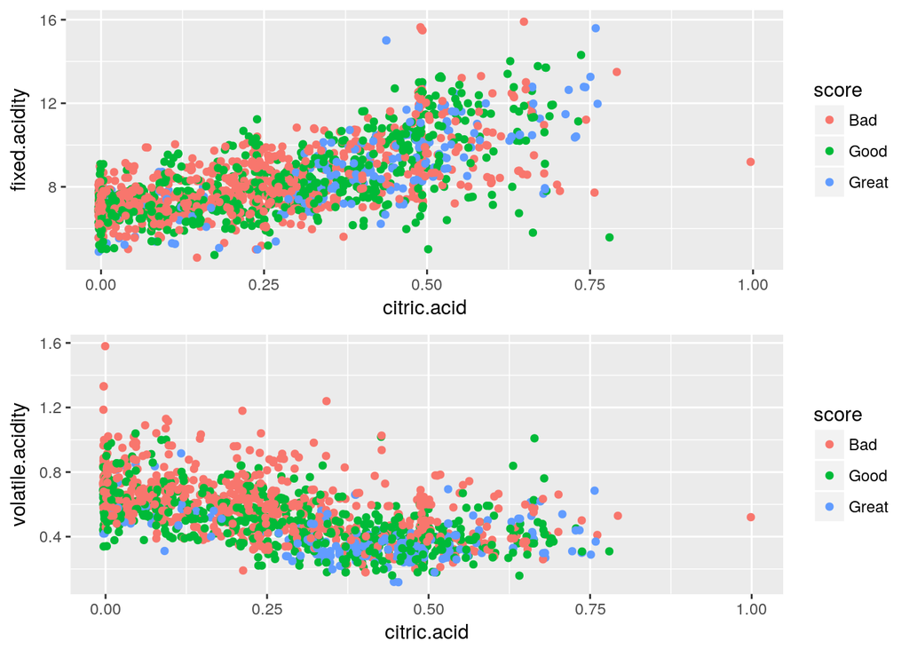

As mentioned before, there is a stong relationship between acidity and citric acid  
content. Additionally, great wines seem to have less violatile acidity and higher  
fixed acidity.

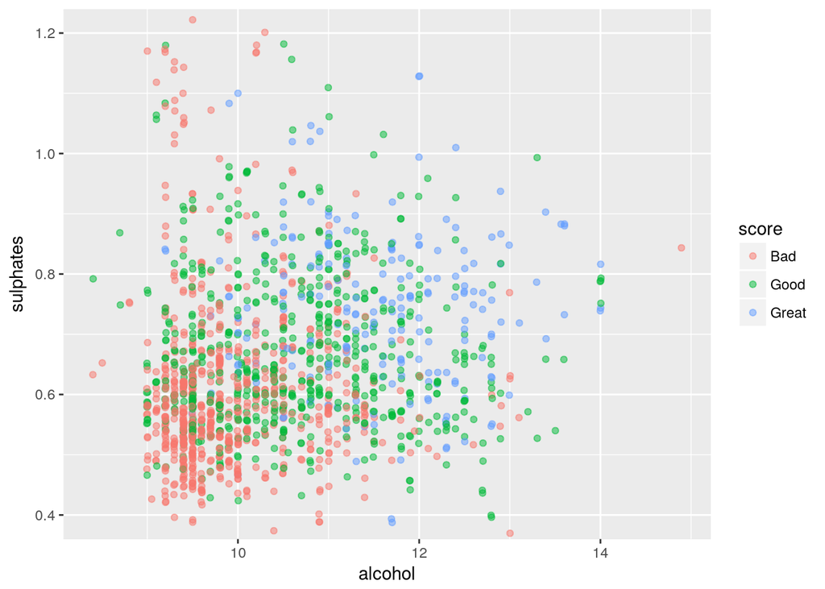

Better quality wines seem to have more sulphates.

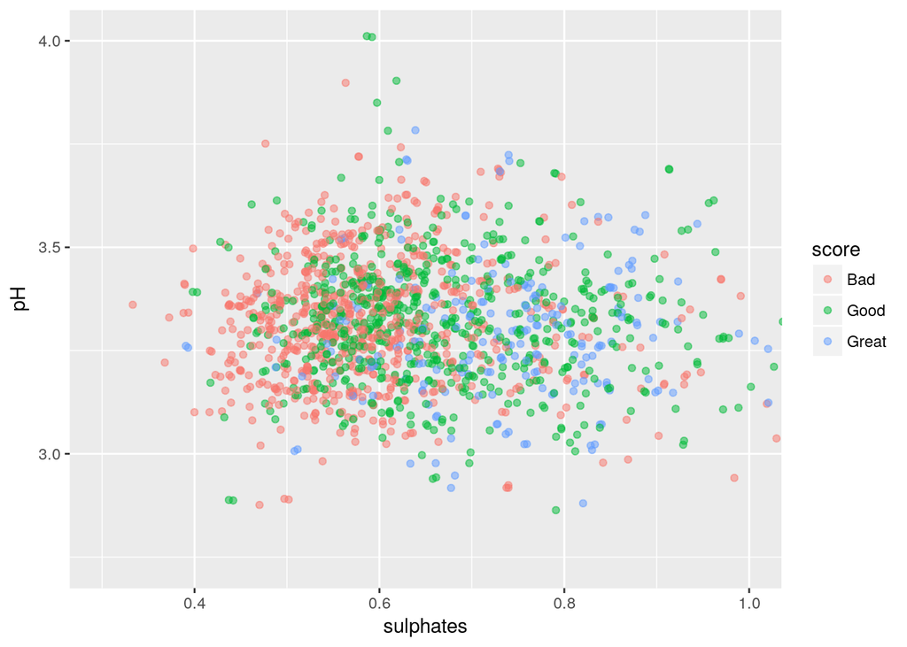

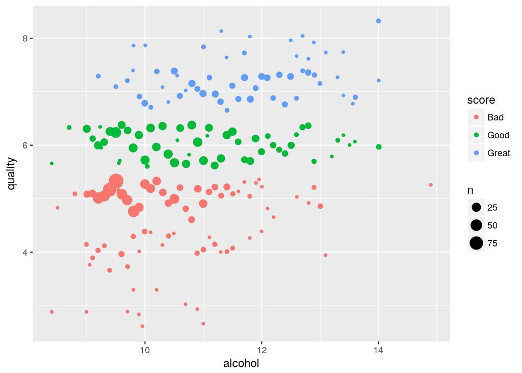

Lower quality wines tend to have lower alcohol content.

## **Multivariate Analysis**

Alcohol content clear plays one of the largest roles in determing the quality of  
the wines. Additional variables such as volatile acidity, fixed acidity, sulphate  
content and citric acid content also play a slightly less significant role in determining  
the quality.

### **Wine Quality Bar Graph**

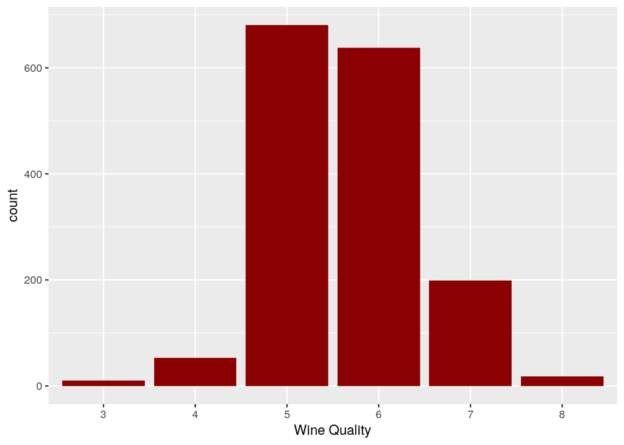

This plot displays the quality distrobution of the wine quality in the dataset  
and gives good insight on the percentage breakdown of the dataset based on quality.

### **Sulphates and Alcohol Content**

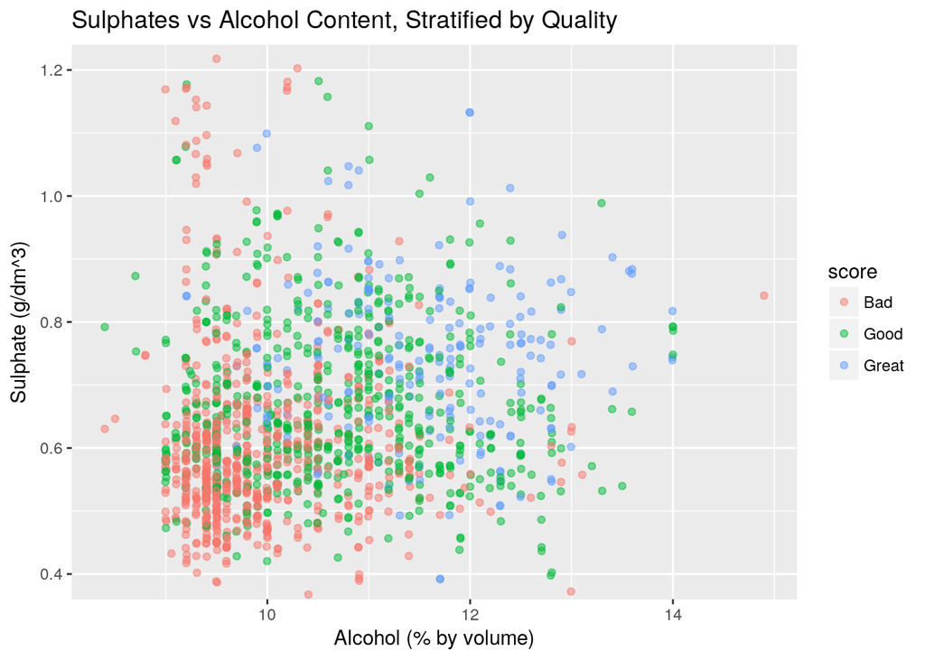

### **Alcohol Content and Quality**

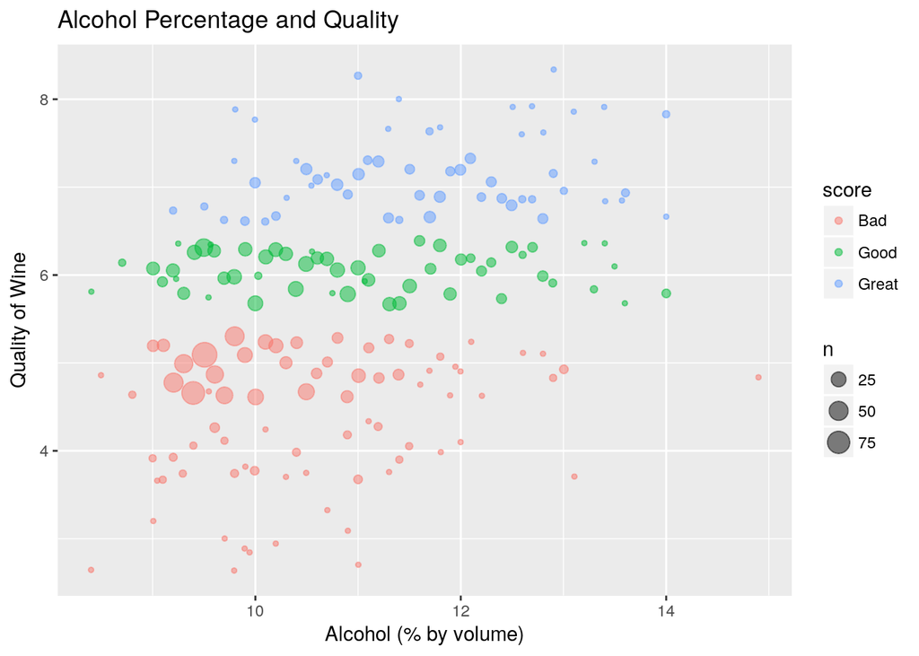

This plot shows the clear stratification of wine quality based on alcohol content.  
I chose this as my final plot because it highlights the fact the alcohol content  
is a large determining factor in the wine’s quality.

## **Sources**

P. Cortez, A. Cerdeira, F. Almeida, T. Matos and J. Reis. Modeling wine preferences by data mining from physicochemical properties. In Decision Support Systems, Elsevier, 47(4):547-553. ISSN: 0167-9236.

Available at: [@Elsevier] http://dx.doi.org/10.1016/j.dss.2009.05.016 [Pre-press (pdf)] http://www3.dsi.uminho.pt/pcortez/winequality09.pdf [bib] http://www3.dsi.uminho.pt/pcortez/dss09.bib

https://s3.amazonaws.com/content.udacity-data.com/courses/ud651/diamondsExample_2016-05.html

https://d17h27t6h515a5.cloudfront.net/topher/2017/February/58af99ac_projecttemplate/projecttemplate.rmd